# Part_II slides

## Part 2 - The impact of user type and gender on the durations time

### by Pius Imwene

## Investigation Overview

On this presentation, I will mainly focus on the following variables to find their relationships. They include durations time for trip, the user type and gender of the participants. I will use the scatterplots and box pot to finding their trend or pattern.Additionally, i will use histogram to investigation the distributions of durations time in seconds after log transformation.

## Dataset Overview

Initially, dataset has 183412 rows and columns of 16. After preliminalry wrangling, the number of rows become 174952 and 20 columns (some columns were added). The columns that are strings are end_station_name, user_type, member_gender,member_gender and bike_share_for_al, start_month, end_month. The other 13 columns (variables) are numerics.

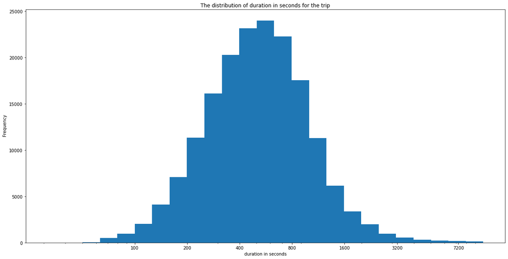

### The relationship between participants' age and durations times(s) after transformed using log scale and inverse

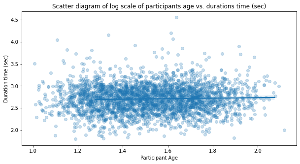

### The relationship between gender and user type.

From the clustered bar chart, it indicate that there is a relationship between user type and gender. For example, males have a higher relationship with user type especially in subscriber than females.

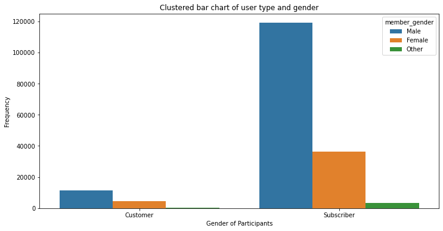